# FM-GPT Tutorial

## Data Generation

```r
set.seed(1423)
dat <- gen_twas_sets(n_qtl = 100, n_gwas = 5000, n_genes = 10, snps_per_gene = 10, block_sizes = rep(10, 10), rho_between = 0.33, rho_within = 0.66, response_types = c(10, 0, 0), k = 3, maf = 0.24, choice = "genes", sig_rho = 0.66, pi0 = 1, pi1 = 0.1, pi2 = 1, expression_heritability = 0.1,sigma2 = 1, binflate = 0.05)
```

The `dat` object contains the following elements:

```r
names(dat)
```

```
##  [1] "G_qtl"     "G_gwas"    "E_qtl"     "SNP_coef"  "Yl"        "Yo"
##  [7] "Lambda"    "Sigma"     "group"     "A"         "beta"      "r"
## [13] "responses" "U"         "Ucov"      "LD"
```

The most important elements are: `G_qtl` and `G_gwas`, which contain the genotype data for the eQTL and GWAS studies, `E_qtl`, which contains the gene expression data for the eQTL study, `Yl` and `Yo` which contain the latent factors and observed outcome data, `Lambda`, which contains the loading matrix, `beta` which contains the gene causality pattern for the latent factors, and finally `responses`, which categorizes the response type of the outcome data (e.g. continuous, binary, count).

Now let’s view the gene causality pattern.

```r
dat$beta
```

```
##            [,1]      [,2]      [,3]
##  [1,] 0.0000000 0.0000000 0.0000000
##  [2,] 0.0000000 0.0000000 0.0000000
##  [3,] 0.1715735 0.3307978 0.1299771
##  [4,] 0.0000000 0.0000000 0.0000000
##  [5,] 0.0000000 0.0000000 0.0000000
##  [6,] 0.0000000 0.0000000 0.0000000
##  [7,] 0.0000000 0.0000000 0.0000000
##  [8,] 0.0000000 0.0000000 0.0000000
##  [9,] 0.0000000 0.0000000 0.0000000
## [10,] 0.0000000 0.0000000 0.0000000
```

# Computation

Now we shall estimate the predicted expression from the synthetic data. We will use a spike-and-slab regression implementation.

```r
est_coef_mat <- matrix(nrow = nrow(dat$SNP_coef), ncol = ncol(dat$SNP_coef))

for(j in 1:ncol(dat$SNP_coef)) {
  tmp_out <- lm.spike(scale(dat$E_qtl[,j], scale = FALSE) ~ scale(dat$G_qtl, scale = FALSE)+0, niter = 1000)
  est_coef_mat[,j] <- apply(tmp_out$beta[751:1000,], 2, median)
}
```

For example, for the first gene, here is the weight vector for its 10 SNPs:

```r
est_coef_mat[1:10,1]
```

```
##  [1]  0.000000  0.000000  0.000000  0.000000 -1.719266  0.000000  0.000000
##  [8]  0.000000  0.000000 -1.101098
```

Now, we will generate the predicted gene expressions and fit the model.

```r
E_gwas <- dat$G_gwas %*% est_coef_mat
fit <- FMGPT(X = scale(E_gwas, scale = FALSE), Y = scale(dat$Yo, scale = FALSE), A = 0*dat$A, group = seq(1, 10), response_types = dat$responses, epsilon = 0.4, B = 3000, burnin = 2000, thin = 1, k_fix = NULL, scale.eta = FALSE)
```

We can first assess the total number of factors the model has suggested exist in the data:

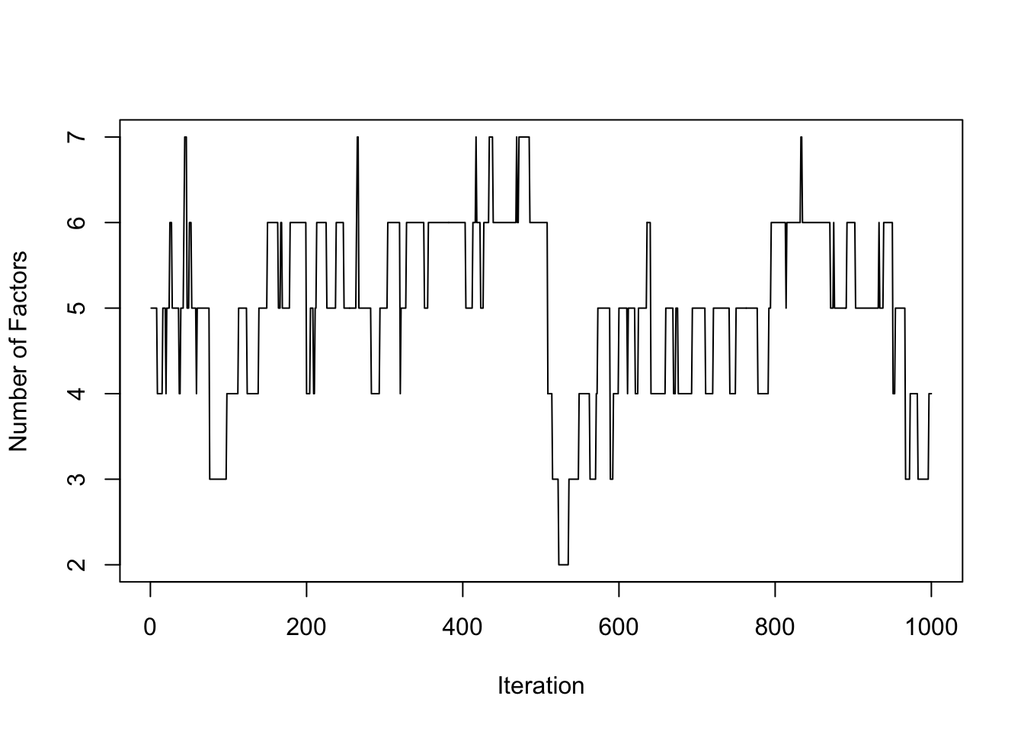

```r
ts.plot(fit$kstar, xlab = "Iteration", ylab = "Number of Factors")
```

Additionally, we can view the loading matrix pattern. Based on the trace plot of the number of factors, we will view the loadings for the first six factors:

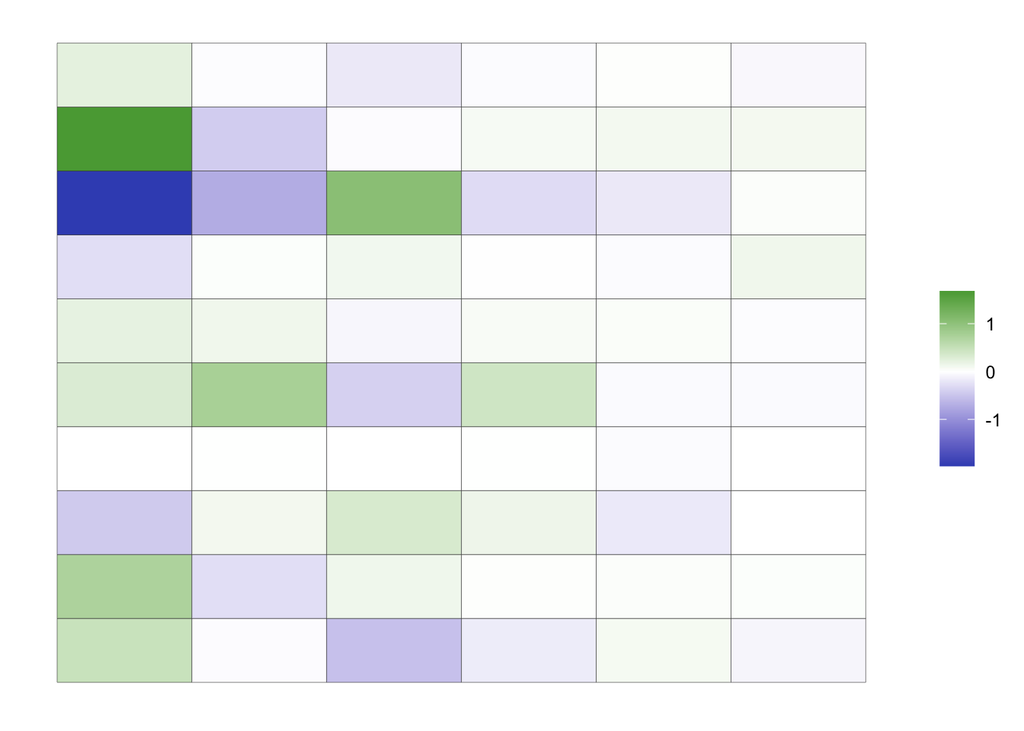

```r
infinitefactor::plotmat(t(apply(fit$lambda, c(2, 3),mean, na.rm = TRUE))[,1:6])
```

We can also do more classic methods of factor determination, such as the correlation plot and the scree plot:

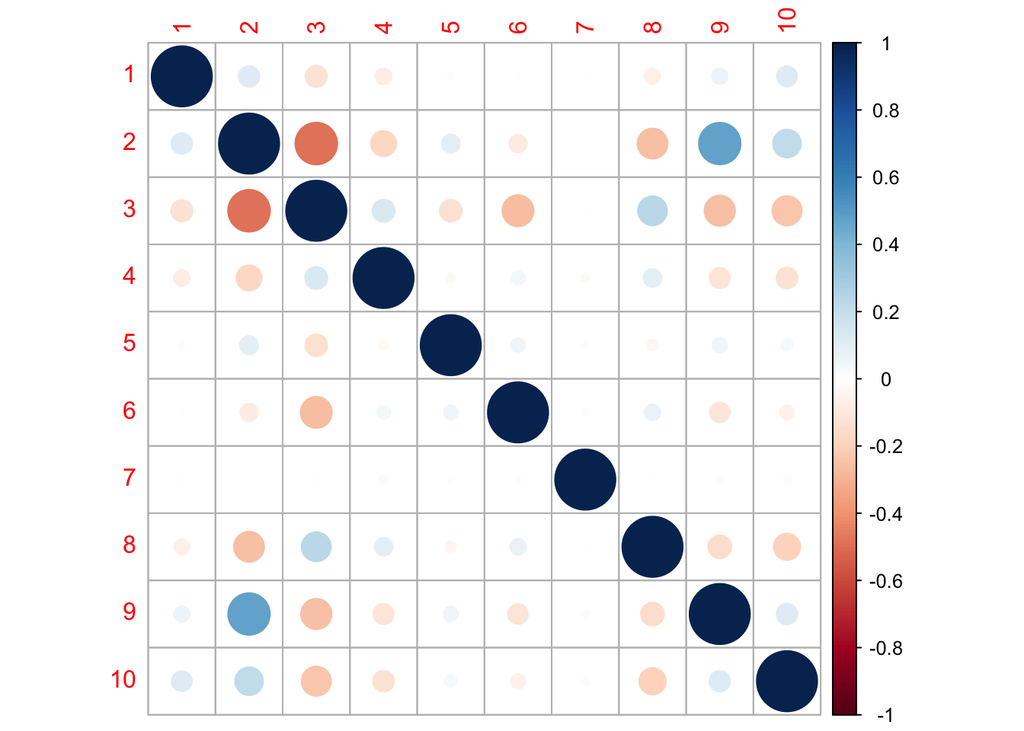

```r
corrplot::corrplot(cor(dat$Yo))
```

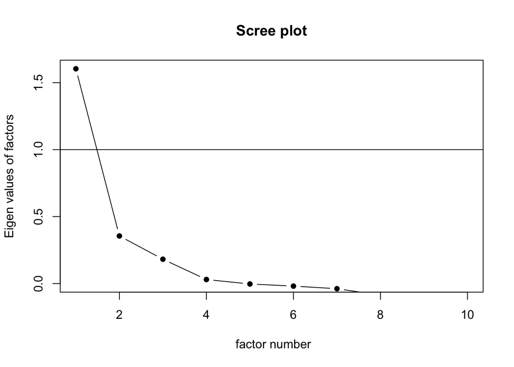

```r
psych::scree(cor(dat$Yo), pc = FALSE)
```

Furthermore, we can try to suppress certain loadings to zero. Looking at the posterior mean of the loading matrix for the first three factors, we have:

```r
t(apply(fit$lambda, c(2, 3),mean, na.rm = TRUE))[,1:3]
```

```
##               [,1]         [,2]         [,3]
##  [1,]  0.228136006 -0.021832330 -0.188681266
##  [2,]  1.678967752 -0.421212221 -0.026450774
##  [3,] -1.975485138 -0.720422383  1.050560210
##  [4,] -0.275308863  0.027476766  0.112662100
##  [5,]  0.208116483  0.127676866 -0.068475715
##  [6,]  0.312933988  0.765620239 -0.387355095
##  [7,] -0.003455489  0.009329259  0.002512951
##  [8,] -0.447556340  0.106884653  0.345457250
##  [9,]  0.719770599 -0.270749420  0.131224191
## [10,]  0.471726854 -0.027442417 -0.529810597
```

Now, we’ll apply the post-hoc unit scaling adjustment to determine which loadings to keep within each factor.

```r
dim(fit$lambda)
```

```
## [1] 1000   10   10
```

```r
lambda_draws <- fit$lambda[,1:3,]
for(b in 1:750) {
  for(k in 1:3) {
    lambda_draws[b,k,] <- lambda_draws[b,k,] / sqrt(sum(lambda_draws[b,k,]^2))
  }
}
t(apply(lambda_draws, c(2, 3),mean, na.rm = TRUE))[,1:3]
```

```
##               [,1]          [,2]         [,3]
##  [1,]  0.125128803 -0.0237267830 -0.108230296
##  [2,]  0.871217714 -0.3160903453 -0.037762536
##  [3,] -1.103193680 -0.5374466405  0.314718766
##  [4,] -0.142874434  0.0007746511  0.073747340
##  [5,]  0.106915864  0.1040648931  0.005468073
##  [6,]  0.193282812  0.5339733095  0.071825144
##  [7,] -0.004489443 -0.0034926657  0.018296691
##  [8,] -0.256985029  0.0552749793  0.273067655
##  [9,]  0.365444884 -0.2025981749  0.021096815
## [10,]  0.267596961 -0.0043584861 -0.364186470
```

This matrix gives the relative magnitude of each loading in each factor. We’ll keep only those loadings with an absolute magnitude > 0.10.

```r
lambda_keep <- t(apply(lambda_draws, c(2, 3),mean, na.rm = TRUE))[,1:3]
lambda_keep[abs(lambda_keep) < 0.1] <- 0
t(apply(fit$lambda, c(2, 3),mean, na.rm = TRUE))[,1:3] * (abs(lambda_keep) > 0.10)
```

```
##             [,1]       [,2]       [,3]
##  [1,]  0.2281360  0.0000000 -0.1886813
##  [2,]  1.6789678 -0.4212122  0.0000000
##  [3,] -1.9754851 -0.7204224  1.0505602
##  [4,] -0.2753089  0.0000000  0.0000000
##  [5,]  0.2081165  0.1276769  0.0000000
##  [6,]  0.3129340  0.7656202  0.0000000
##  [7,]  0.0000000  0.0000000  0.0000000
##  [8,] -0.4475563  0.0000000  0.3454572
##  [9,]  0.7197706 -0.2707494  0.0000000
## [10,]  0.4717269  0.0000000 -0.5298106
```

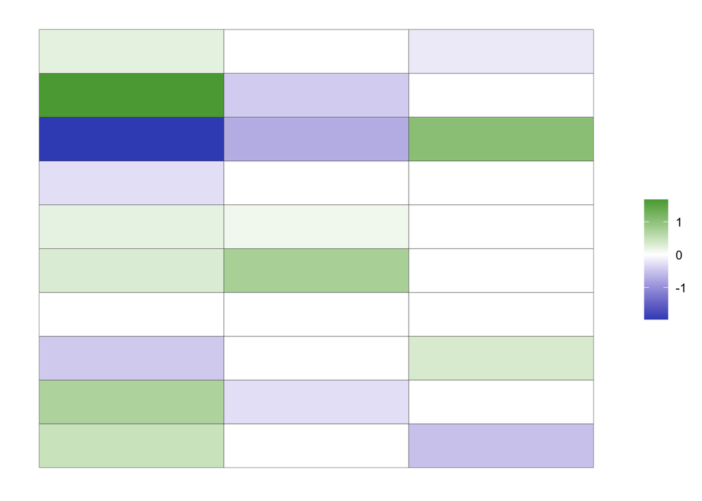

```r
infinitefactor::plotmat(t(apply(fit$lambda, c(2, 3),mean, na.rm = TRUE))[,1:3] * (abs(lambda_keep) > 0.10))
```

Finally, now that we’ve determined to keep 3 factors, we can look at the omnibus PIP of the genes for these three factors:

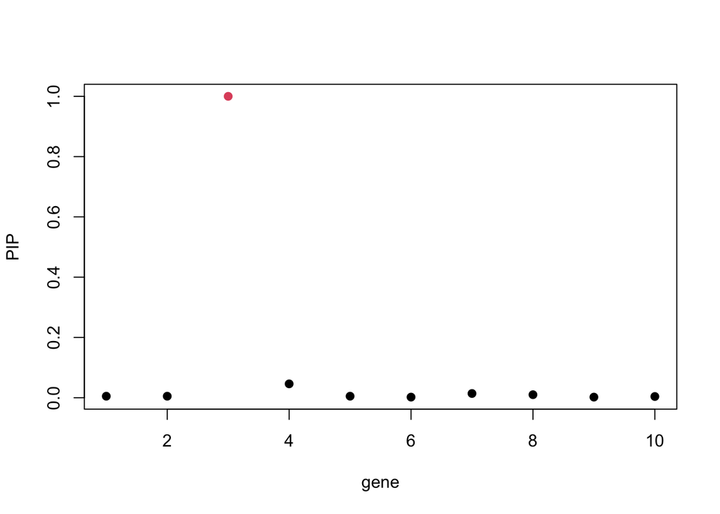

```r
plot(twas_pip(fit, 3), xlab = "gene", ylab= "PIP", col = dat$A+1, pch = 19)
```

Clearly the gene with the highest PIP is the 3rd gene, which matches the gene causality pattern shown above.